**What is this notebook?**  
This notebook contains all the experiments for training and evaluating the model.

# Imports & Data Formatting

```python
from data_pipeline import data_pipeline

import matplotlib as mpl
import matplotlib.pyplot as plt
import numpy as np
import pandas as pda
from scipy.stats import gaussian_kde
from sklearn.ensemble import RandomForestRegressor, GradientBoostingRegressor
from sklearn.linear_model import ElasticNet, LinearRegression
from xgboost import XGBRegressor
```

```python
mpl.rcParams['figure.dpi'] = 175
plt.rcParams['figure.figsize'] = (6,4)

%load_ext autoreload
%autoreload 2
```

```python
pipeline = data_pipeline()
pipeline.perform_full_data_pipeline()

dataset = pipeline.dataset
```

```python
training_split_percent = 0.8
test_split_percent = 1 - training_split_percent

dataset.set_index('organization_id', inplace=True)
eval_columns = ['month_1_cpv', 'month_2_cpv', 'month_3_cpv']
training_columns = [col for col in dataset.columns if col not in eval_columns]

X = dataset.loc[:, training_columns]
month_1 = dataset.loc[:, 'month_1_cpv']
month_2 = dataset.loc[:, 'month_2_cpv']
month_3 = dataset.loc[:, 'month_3_cpv']

row_shuffle = np.random.choice(range(X.shape[0]), replace=False, size=X.shape[0])
cutoff_index = int(training_split_percent * row_shuffle.shape[0])

training_row_indices = row_shuffle[:cutoff_index]
test_row_indices = row_shuffle[cutoff_index:]

X_train = X.iloc[training_row_indices, :].values
m1_train = month_1.iloc[training_row_indices].values
m2_train = month_2.iloc[training_row_indices].values
m3_train = month_3.iloc[training_row_indices].values

X_test = X.iloc[test_row_indices, :].values
m1_test = month_1.iloc[test_row_indices].values
m2_test = month_2.iloc[test_row_indices].values
m3_test = month_3.iloc[test_row_indices].values
```

# Month 1 Modeling

## ElasticNet Regression

```python
# I didn't normalize the data, so we're doing it here.
en = ElasticNet(normalize=True)
en.fit(X_train, m1_train)

predictions = en.predict(X_test)
errors = [np.abs(actual - pred) for pred, actual in zip(m1_test, predictions)]
print("Mean absolute error:", np.average(errors))
```

```
Mean absolute error: 1255.2400061333783
```

## Random Forest Regression

```python
rf = RandomForestRegressor(n_estimators=10)
rf.fit(X_train, m1_train)

predictions = rf.predict(X_test)
errors = [np.abs(actual - pred) for pred, actual in zip(m1_test, predictions)]
print("Mean absolute error:", np.average(errors))
```

```
Mean absolute error: 1047.8289040038942
```

## Gradient Boosting Regression

```python
gb = GradientBoostingRegressor(n_estimators=10)
gb.fit(X_train, m1_train)

predictions = gb.predict(X_test)
errors = [np.abs(actual - pred) for pred, actual in zip(m1_test, predictions)]
print("Mean absolute error:", np.average(errors))
```

```
Mean absolute error: 1100.4221246478637
```

## XGBoost Regression

Let's set the number of estimators very low since the dataset is so small. That way we can avoid overfitting.

```python
xgb = XGBRegressor(objective="reg:squarederror", n_estimators=10)
xgb.fit(X_train, m1_train)

predictions = xgb.predict(X_test)
errors = [np.abs(actual - pred) for pred, actual in zip(m1_test, predictions)]
print("Mean absolute error:", np.average(errors))
```

```
Mean absolute error: 954.2656557237254
```

Let's experiment with adjusting n_estimators.

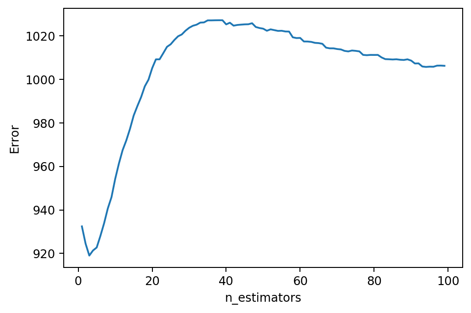

```python
maes = []
median_errors = []
for ests in np.arange(1,100):
    xgb = XGBRegressor(objective="reg:squarederror", n_estimators=ests)
    xgb.fit(X_train, m1_train)

    predictions = xgb.predict(X_test)
    errors = [np.abs(actual - pred) for pred, actual in zip(m1_test, predictions)]
    maes.append(np.average(errors))

plt.plot(np.arange(1,100), maes, label="Mean Absolute Error")
plt.xlabel("n_estimators")
plt.ylabel("Error")
plt.show()
```

## Is this MAE good?

Let's compare our predictions to the magnitudes of the Card Payment Volume values. (for month 1)

```python
xgb = XGBRegressor(objective="reg:squarederror", n_estimators=10)
xgb.fit(X_train, m1_train)

m1_predictions = xgb.predict(X_test)
m1_errors = [np.abs(actual - pred) for pred, actual in zip(m1_test, predictions)]
```

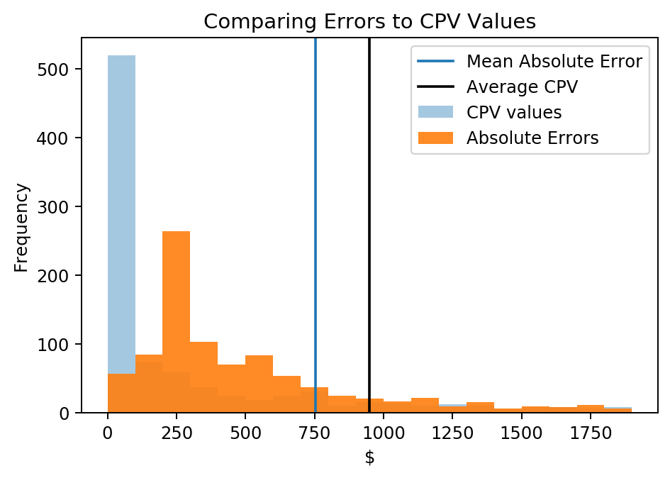

```
Average Card Payment Volume: 949.0515064676619
```

```python
plt.hist(m1_test, label="CPV values", alpha=0.4, bins=np.arange(0,2000, 100))
plt.hist(m1_errors, label="Absolute Errors", alpha=0.9, bins=np.arange(0,2000, 100))
plt.axvline(754, label="Mean Absolute Error")
plt.axvline(np.average(m1_test), label="Average CPV", color='k')
plt.title("Comparing Errors to CPV Values")
plt.xlabel("$")
plt.ylabel("Frequency")
plt.legend()

plt.show()

print("Average Card Payment Volume:", np.average(m1_test))
```

What if we always predicted the average CPV during the training period (adjusted to predict for 30 days)?

```python
X_4 = X.loc[:, ['cpv']]
X_train_4 = X_4.iloc[training_row_indices, :].values
X_test_4 = X_4.iloc[test_row_indices, :].values

lr = LinearRegression()
lr.fit(X_train_4, m1_train)

training_average = (30 / 14 ) * np.average(X_train_4)
errors = [np.abs(training_average - actual) for actual in m1_test]
print("Mean absolute error:", np.mean(errors))
```

```
Mean absolute error: 1316.385904958576
```

Fortunately, we are doing better than just always predicting the average.

What if we always predicted the median, though?

```python
training_median = np.median(X_train_4) * (30 / 14)
errors = [np.abs(training_median - actual) for actual in m1_test]
print("Mean absolute error:", np.mean(errors))
```

```
Mean absolute error: 941.5485173560769
```

We are doing slightly better than predicting the median for the training period as well.

Let's see if we can make some tweaks to increase the model performance.

## Removing Dummy Variables

```python
X_2 = X.loc[:, ['cpv', 'transaction_count']]
X_train_2 = X_2.iloc[training_row_indices, :].values
X_test_2 = X_2.iloc[test_row_indices, :].values
```

```python
gb = XGBRegressor(objective="reg:squarederror", n_estimators=2)
gb.fit(X_train_2, m1_train)

predictions = gb.predict(X_test_2)
errors = [np.abs(actual - pred) for pred, actual in zip(m1_test, predictions)]
print("Mean absolute error:", np.average(errors))
```

```
Mean absolute error: 926.1031361476555
```

This slightly increases the MAE, so we will include the dummy variables, though they appear to not be contributing very much.

## Removing Outliers

Our big MAE may be coming from outliers, so let's try removing those from the training dataset. I don't know where to set the outlier threshold, so let's just try different thresholds and see which one has the lowest MAE.

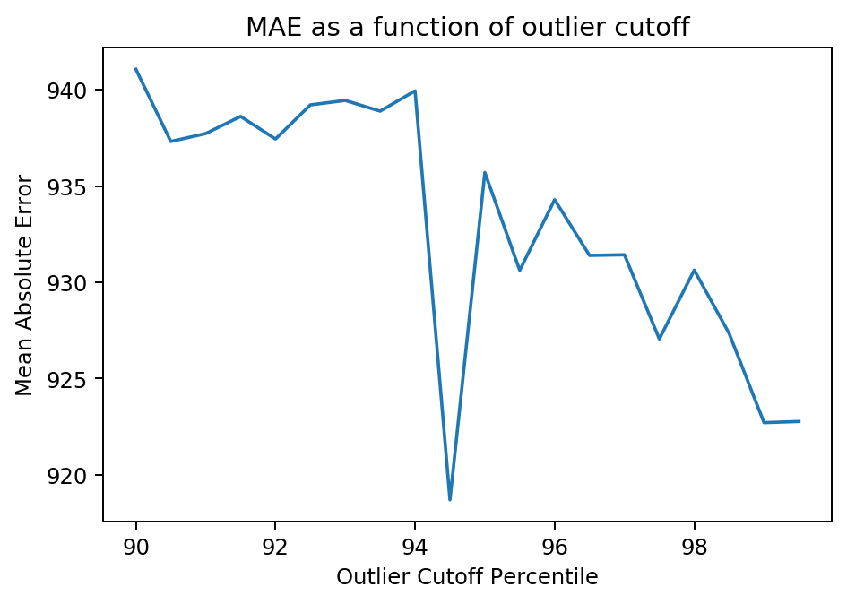

```python
thresholds = np.arange(90,100,0.5)
maes = []

for threshold in thresholds:
    X_train_3 = X.iloc[training_row_indices, :]
    X_test_3 = X.iloc[test_row_indices, :].values
    outlier_threshold = np.percentile(X_train_3, threshold)
    inclusion_filter = [True if val < outlier_threshold else False for val in X_train_3['cpv'].values]

    X_train_3 = X_train_3.loc[inclusion_filter, :].values
    y_train_3 = m1_train[inclusion_filter]

    gb = XGBRegressor(objective="reg:squarederror", n_estimators=2)
    gb.fit(X_train_3, y_train_3)

    predictions = gb.predict(X_test_3)
    errors = [np.abs(actual - pred) for pred, actual in zip(m1_test, predictions)]
    maes.append(np.average(errors))

plt.plot(thresholds, maes)
plt.title("MAE as a function of outlier cutoff")
plt.ylabel("Mean Absolute Error")
plt.xlabel("Outlier Cutoff Percentile")
plt.show()
```

It looks like the top performance is when we don't remove any outliers. I'm assuming the 95 plummet is a fluke from removing a single datapoint since it is such an outlier from the overall trend line. I would verify this given more time.

## Month 1 Model Conclusions

For month 1, our best model is XGBoost setting n_estimators to 2 with no outlier removal.

# Modeling for Month 2

Let's start by using the same parameters for month 2 and compare this to predicting the median for the training period.

```python
gb = XGBRegressor(objective="reg:squarederror", n_estimators=2)
gb.fit(X_train, m2_train)

predictions = gb.predict(X_test)
errors = [np.abs(actual - pred) for pred, actual in zip(m2_test, predictions)]
print(np.average(errors))
```

```
1004.8823591085836
```

Let's compare that to predicting the median during the training period.

```python
training_median = np.median(X_train[:, 0]) * (30 / 14)
errors = [np.abs(training_median - actual) for actual in m2_test]
print("Mean absolute error (month 2):", np.mean(errors))
```

```
Mean absolute error (month 2): 1017.8308391186929
```

It looks like this performance is right about at random, so we need to do some hyperparameter tuning.

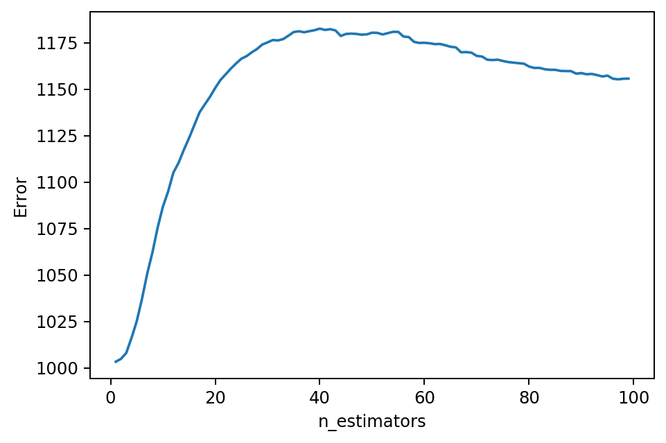

```python
maes = []
median_errors = []
for ests in np.arange(1,100):
    xgb = XGBRegressor(objective="reg:squarederror", n_estimators=ests)
    xgb.fit(X_train, m2_train)

    predictions = xgb.predict(X_test)
    errors = [np.abs(actual - pred) for pred, actual in zip(m2_test, predictions)]
    maes.append(np.average(errors))

plt.plot(np.arange(1,100), maes, label="Mean Absolute Error")
plt.xlabel("n_estimators")
plt.ylabel("Error")
plt.show()
```

```python
gb = XGBRegressor(objective="reg:squarederror", n_estimators=1)
gb.fit(X_train, m2_train)

predictions = gb.predict(X_test)
errors = [np.abs(actual - pred) for pred, actual in zip(m2_test, predictions)]
print(np.average(errors))
```

```
1003.336882005984
```

Since using a single estimator maximizes performance, let's simplify and only look at CPV as an input feature, seeing if that increases performance a bit more.

```python
gb = XGBRegressor(objective="reg:squarederror", n_estimators=1)
gb.fit(X_train[:, 0].reshape(-1,1), m2_train)

predictions = gb.predict(X_test[:, 0].reshape(-1,1))
errors = [np.abs(actual - pred) for pred, actual in zip(m2_test, predictions)]
print(np.average(errors))
```

```
1003.444661786889
```

This increases the MAE slightly. What if we remove the dummy variables?

```python
gb = XGBRegressor(objective="reg:squarederror", n_estimators=1)
gb.fit(X_train[:, 0:2], m2_train)

predictions = gb.predict(X_test[:, 0:2])
errors = [np.abs(actual - pred) for pred, actual in zip(m2_test, predictions)]
print(np.average(errors))
```

```
1003.336882005984
```

## Month 2 Modeling Conclusion

The top performing model for month 2 is XGBoost with n_estimators = 1.

# Modeling for Month 3

```python
gb = XGBRegressor(objective="reg:squarederror", n_estimators=1)
gb.fit(X_train, m3_train)

predictions = gb.predict(X_test)
errors = [np.abs(actual - pred) for pred, actual in zip(m3_test, predictions)]
print(np.average(errors))
```

```
960.6114004746958
```

Once again, let's compare this to predicting the median for the training period.

```python
training_median = np.median(X_train[:, 0]) * (30 / 14)
errors = [np.abs(training_median - actual) for actual in m3_test]
print("Mean absolute error (month 3):", np.mean(errors))
```

```
Mean absolute error (month 3): 972.6522329637528
```

Let's look over n_estimator values for the month 3 model.

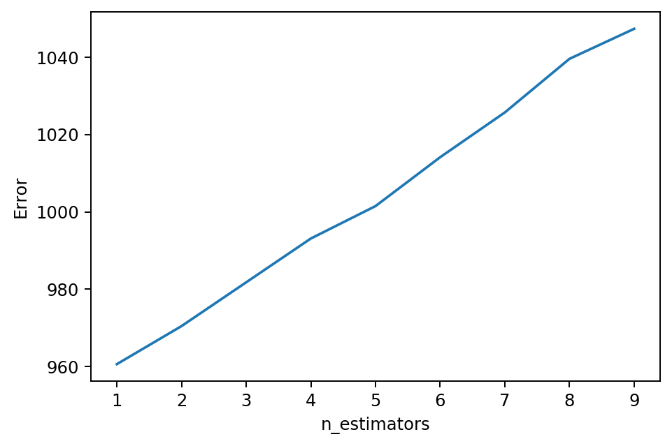

```python
maes = []
median_errors = []
for ests in np.arange(1,10):
    xgb = XGBRegressor(objective="reg:squarederror", n_estimators=ests)
    xgb.fit(X_train, m3_train)

    predictions = xgb.predict(X_test)
    errors = [np.abs(actual - pred) for pred, actual in zip(m3_test, predictions)]
    maes.append(np.average(errors))

plt.plot(np.arange(1,10), maes, label="Mean Absolute Error")
plt.xlabel("n_estimators")
plt.ylabel("Error")
plt.show()
```

And now let's compare this model to training purely on CPV for the first 14 days.

```python
gb = XGBRegressor(objective="reg:squarederror", n_estimators=1)
gb.fit(X_train[:, 0:1], m3_train)

predictions = gb.predict(X_test[:, 0:1])
errors = [np.abs(actual - pred) for pred, actual in zip(m3_test, predictions)]
print(np.average(errors))
```

```
956.7432829818681
```

It looks like the performance is about the same here.

## Month 3 Modeling Conclusion

The best model for month 3 is XGBoost with n_estimators=1. For simplicity's sake, we can only include the CPV for the first 14 days as an input feature.

# Next Steps

If I had more time, I would:

- do more hyperparameter tuning.
- Add in month of year as a feature.
- Experiment with CatBoost (with no dummy variables).